# Tamoxifen resistance in ER+ breast cancer cell lines (GSE111151)

```r
knitr::opts_knit$set(root.dir = here::here())
library(tidyverse)
library(here)
library(DESeq2)
library(edgeR)
library(limma)
library(pheatmap)
library(ggrepel)
library(fgsea)
library(msigdbr)
dir.create(here("analysis/results/figures"), showWarnings = FALSE, recursive = TRUE)
dir.create(here("analysis/results/tables"), showWarnings = FALSE, recursive = TRUE)
```

## 1. Data

Transcript-level quantification from Salmon (run on [Galaxy Australia](https://usegalaxy.org.au) against GENCODE v46 transcripts), summarised to genes with tximport.

```r
library(tximport)

# Sample annotation (from GEO) joined to SRA run accessions (from SRA Run Selector)
samples <- read_csv("metadata/samples_geo.csv", show_col_types = FALSE)
sra <- read_csv("metadata/SraRunTable.csv", show_col_types = FALSE)
# The GSM column is named differently across SRA Run Selector exports, so find it by content
gsm_col <- names(sra)[map_lgl(sra, \(x) all(str_detect(x, "^GSM[0-9]+$"), na.rm = TRUE) && any(!is.na(x)))][1]
if (is.na(gsm_col)) stop("No GSM column in metadata/SraRunTable.csv. Columns: ", paste(names(sra), collapse = ", "))
runs <- tibble(run = sra$Run, gsm = sra[[gsm_col]])
info_runs <- inner_join(runs, samples, by = "gsm") |>
  mutate(condition = factor(condition, levels = c("parental", "resistant")),
         cell_line = factor(cell_line))
if (n_distinct(info_runs$gsm) != 11) stop("Expected 11 GEO samples, matched ", n_distinct(info_runs$gsm), ". Check metadata/SraRunTable.csv.")

# One Salmon quant file per run, named by its SRR accession (e.g. data/salmon/SRRxxxxxxx.tabular)
files <- list.files("data/salmon", pattern = "^SRR[0-9]+", full.names = TRUE)
names(files) <- str_extract(basename(files), "^SRR[0-9]+")
files <- files[info_runs$run]
stopifnot(!anyNA(files))

# Map transcripts to genes from the GENCODE v46 FASTA headers:
# >ENST...|ENSG...|OTTHUMG|OTTHUMT|tx_name|gene_name|length|biotype|
tx2gene_file <- "data/tx2gene_gencode_v46.tsv"
if (!file.exists(tx2gene_file)) {
  fa <- "data/gencode.v46.transcripts.fa.gz"
  if (!file.exists(fa)) {
    options(timeout = 3600)
    download.file("https://ftp.ebi.ac.uk/pub/databases/gencode/Gencode_human/release_46/gencode.v46.transcripts.fa.gz",
                  fa, mode = "wb")
  }
  headers <- str_subset(read_lines(fa), "^>") |> str_remove("^>")
  tibble(header = headers) |>
    separate_wider_delim(header, "|", names = c("tx", "gene_id", NA, NA, NA, "gene_name"),
                         too_many = "drop", cols_remove = FALSE) |>
    write_tsv(tx2gene_file)
}
tx2gene <- read_tsv(tx2gene_file, show_col_types = FALSE)

# Salmon names are either full headers (ENST...|ENSG...|...) or bare transcript IDs (--gencode)
tx_names <- read_tsv(files[1], show_col_types = FALSE)$Name
key <- if (all(str_detect(tx_names, fixed("|")))) "header" else "tx"
if (!all(str_detect(tx_names, fixed(".")))) tx2gene <- mutate(tx2gene, tx = str_remove(tx, "\\.[0-9]+$"))
tx2gene <- tx2gene |> select(name = all_of(key), gene_id, gene_name)
matched <- mean(tx_names %in% tx2gene$name)
if (matched < 0.95) stop(sprintf("Only %.0f%% of Salmon transcript names match GENCODE v46, e.g. %s",
                                 100 * matched, paste(head(tx_names, 3), collapse = ", ")))
gene_names <- distinct(tx2gene, gene_id, gene_name)

txi <- tximport(files, type = "salmon", tx2gene = select(tx2gene, name, gene_id))
```

```
## reading in files with read_tsv
```

```
## 1 2 3 4 5 6 7 8 9 10 11
## summarizing abundance
## summarizing counts
## summarizing length
```

```r
info <- info_runs |> column_to_rownames("run")
info |> select(gsm, title, cell_line, condition)
```

```
##                   gsm        title cell_line condition
## SRR6784695 GSM3024053        MCF-7      MCF7  parental
## SRR6784696 GSM3024054   MCF-7 Tam1      MCF7 resistant
## SRR6784697 GSM3024055        T-47D      T47D  parental
## SRR6784698 GSM3024056   T-47D Tam1      T47D resistant
## SRR6784699 GSM3024057   T-47D Tam2      T47D resistant
## SRR6784700 GSM3024058      ZR-75-1     ZR751  parental
## SRR6784701 GSM3024059 ZR-75-1 Tam1     ZR751 resistant
## SRR6784702 GSM3024060 ZR-75-1 Tam2     ZR751 resistant
## SRR6784703 GSM3024061       BT-474     BT474  parental
## SRR6784704 GSM3024062  BT-474 Tam1     BT474 resistant
## SRR6784705 GSM3024063  BT-474 Tam2     BT474 resistant
```

## 2. Exploratory analysis

```r
dds <- DESeqDataSetFromTximport(txi, info, design = ~ cell_line + condition)
```

```
## using counts and average transcript lengths from tximport
```

```r
# Merge sequencing runs that belong to the same GEO sample
if (anyDuplicated(info$gsm)) dds <- collapseReplicates(dds, groupby = info$gsm, run = rownames(info))
colnames(dds) <- make.names(colData(dds)$title)
info <- as.data.frame(colData(dds))
dds <- dds[rowSums(counts(dds) >= 10) >= 3, ]
vsd <- vst(dds, blind = TRUE)
```

```
## using 'avgTxLength' from assays(dds), correcting for library size
```

```r
pca <- plotPCA(vsd, intgroup = c("cell_line", "condition"), returnData = TRUE)
```

```
## using ntop=500 top features by variance
```

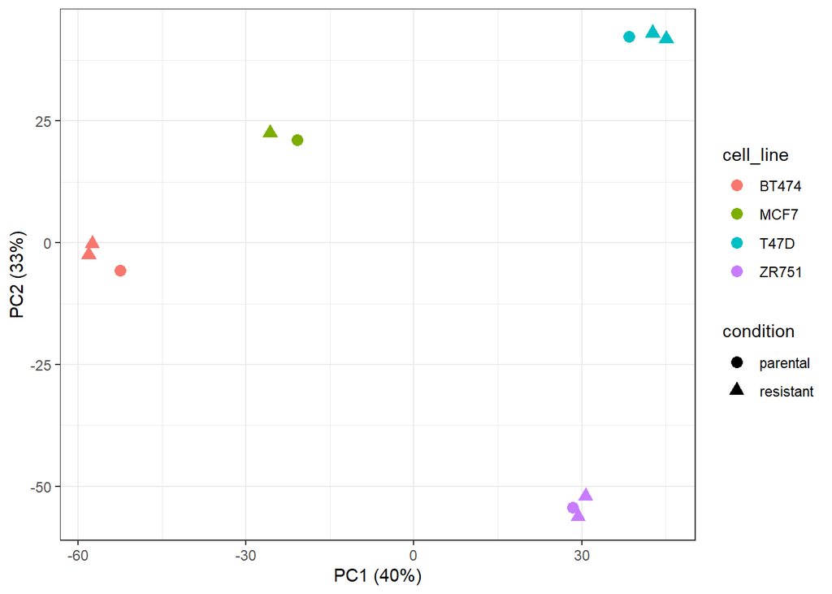

```r
pv <- round(100 * attr(pca, "percentVar"))
p_pca <- ggplot(pca, aes(PC1, PC2, colour = cell_line, shape = condition)) +
  geom_point(size = 3) +
  labs(x = paste0("PC1 (", pv[1], "%)"), y = paste0("PC2 (", pv[2], "%)")) +
  theme_bw()
ggsave("analysis/results/figures/pca.png", p_pca, width = 6, height = 4.5)
p_pca
```

Cell line is expected to dominate PC1; the paired design (`~ cell_line + condition`) removes that effect so the test focuses on resistance.

## 3. Differential expression (DESeq2)

```r
dds <- DESeq(dds)
```

```
## using 'avgTxLength' from assays(dds), correcting for library size
```

```r
res <- lfcShrink(dds, coef = "condition_resistant_vs_parental", type = "apeglm")
```

```
## using 'apeglm' for LFC shrinkage. If used in published research, please cite:
##     Zhu, A., Ibrahim, J.G., Love, M.I. (2018) Heavy-tailed prior distributions for
##     sequence count data: removing the noise and preserving large differences.
##     Bioinformatics. https://doi.org/10.1093/bioinformatics/bty895
```

```r
res_tbl <- as.data.frame(res) |> rownames_to_column("gene_id") |>
  left_join(gene_names, by = "gene_id") |> arrange(padj)
write_csv(res_tbl, "analysis/results/tables/DESeq2_resistant_vs_parental.csv")
sig <- filter(res_tbl, padj < 0.05, abs(log2FoldChange) > 1)
nrow(sig)
```

```
## [1] 134
```

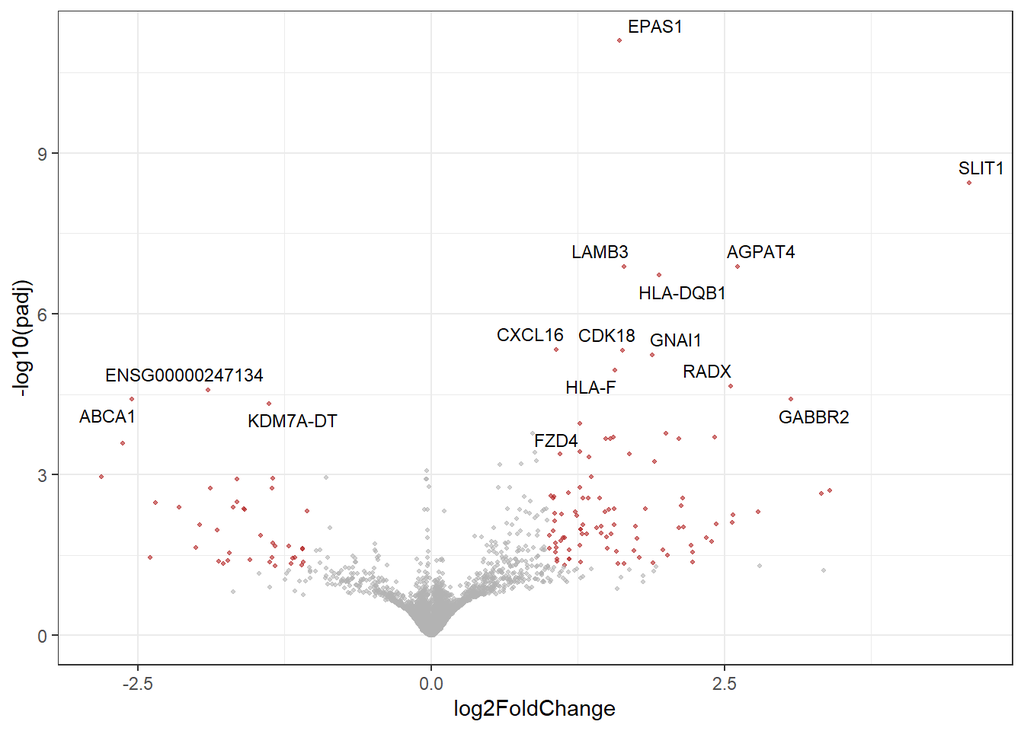

```r
p_vol <- res_tbl |> filter(!is.na(padj)) |>
  mutate(sig = padj < 0.05 & abs(log2FoldChange) > 1) |>
  ggplot(aes(log2FoldChange, -log10(padj), colour = sig)) +
  geom_point(size = 0.8, alpha = 0.6) +
  geom_text_repel(data = ~ head(filter(.x, sig), 15), aes(label = gene_name), size = 3, colour = "black") +
  scale_colour_manual(values = c("grey70", "firebrick")) +
  theme_bw() + theme(legend.position = "none")
ggsave("analysis/results/figures/volcano.png", p_vol, width = 6, height = 5)
p_vol
```

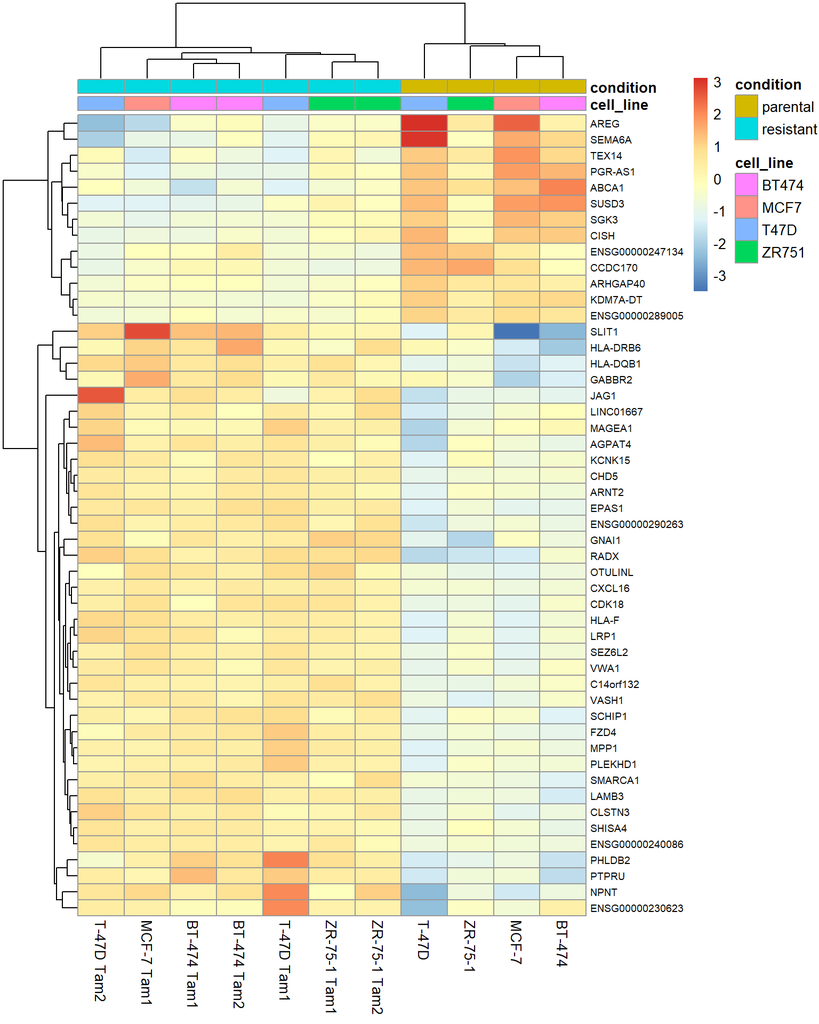

```r
top <- head(sig$gene_id, 50)
# Remove the cell-line baseline for display only, so the heatmap shows the resistance effect
mat <- removeBatchEffect(assay(vsd), batch = vsd$cell_line,
                         design = model.matrix(~ condition, data = info))[top, ]
mat <- mat - rowMeans(mat)
rownames(mat) <- gene_names$gene_name[match(rownames(mat), gene_names$gene_id)]
ph <- pheatmap(mat, annotation_col = info[, c("cell_line", "condition")],
               labels_col = info$title, fontsize_row = 7, silent = TRUE)
ggsave("analysis/results/figures/top50_heatmap.png", ph$gtable, width = 8, height = 10)
ph
```

## 4. Method comparison (edgeR, limma-voom)

```r
design <- model.matrix(~ cell_line + condition, data = info)
y <- DGEList(counts(dds))
y <- normLibSizes(y)

y <- estimateDisp(y, design)
fit_e <- glmQLFit(y, design)
edger <- topTags(glmQLFTest(fit_e, coef = "conditionresistant"), n = Inf)$table

v <- voom(y, design)
limma_res <- topTable(eBayes(lmFit(v, design)), coef = "conditionresistant", number = Inf)

sets <- list(
  DESeq2 = sig$gene_id,
  edgeR  = rownames(edger)[edger$FDR < 0.05 & abs(edger$logFC) > 1],
  limma  = rownames(limma_res)[limma_res$adj.P.Val < 0.05 & abs(limma_res$logFC) > 1]
)
write_csv(rownames_to_column(edger, "gene_id") |> left_join(gene_names, by = "gene_id"),
          "analysis/results/tables/edgeR_resistant_vs_parental.csv")
write_csv(rownames_to_column(limma_res, "gene_id") |> left_join(gene_names, by = "gene_id"),
          "analysis/results/tables/limma_resistant_vs_parental.csv")
sapply(sets, length)
```

```
## DESeq2  edgeR  limma
##    134      8     14
```

```r
# Genes called by all three methods
common <- tibble(gene_id = Reduce(intersect, sets)) |>
  left_join(gene_names, by = "gene_id") |>
  left_join(select(res_tbl, gene_id, DESeq2_log2FC = log2FoldChange, DESeq2_padj = padj), by = "gene_id") |>
  left_join(rownames_to_column(edger, "gene_id") |> select(gene_id, edgeR_logFC = logFC, edgeR_FDR = FDR), by = "gene_id") |>
  left_join(rownames_to_column(limma_res, "gene_id") |> select(gene_id, limma_logFC = logFC, limma_padj = adj.P.Val), by = "gene_id")
write_csv(common, "analysis/results/tables/common_DE_genes.csv")
knitr::kable(common, digits = 3)
```

| gene_id | gene_name | DESeq2_log2FC | DESeq2_padj | edgeR_logFC | edgeR_FDR | limma_logFC | limma_padj |
| --- | --- | --- | --- | --- | --- | --- | --- |
| ENSG00000116016.14 | EPAS1 | 1.603 | 0 | 1.588 | 0.028 | 1.684 | 0.035 |
| ENSG00000187122.17 | SLIT1 | 4.584 | 0 | 4.589 | 0.028 | 4.525 | 0.041 |

## 5. Pathway analysis (GSEA, MSigDB Hallmark)

```r
h <- msigdbr(species = "Homo sapiens", collection = "H")
hallmark <- split(h$gene_symbol, h$gs_name)
# Rank genes by the Wald statistic (lfcShrink output has no stat column)
ranks_all <- results(dds, name = "condition_resistant_vs_parental") |> as.data.frame() |>
  rownames_to_column("gene_id") |> left_join(gene_names, by = "gene_id") |>
  filter(!is.na(stat), !is.na(gene_name)) |> group_by(gene_name) |>
  slice_max(abs(stat), n = 1, with_ties = FALSE) |> ungroup()
ranks <- deframe(select(ranks_all, gene_name, stat))

gsea <- fgsea(hallmark, ranks) |> arrange(padj)
write_csv(mutate(gsea, leadingEdge = map_chr(leadingEdge, paste, collapse = ";")),
          "analysis/results/tables/GSEA_hallmark.csv")
head(gsea[, c("pathway", "NES", "padj")], 15)
```

```
##                                        pathway       NES         padj
##                                         <char>     <num>        <num>
##  1: HALLMARK_EPITHELIAL_MESENCHYMAL_TRANSITION  2.484334 8.732184e-13
##  2:                    HALLMARK_MYC_TARGETS_V1 -2.126848 1.075787e-08
##  3:           HALLMARK_CHOLESTEROL_HOMEOSTASIS  2.174943 2.267213e-06
##  4:                       HALLMARK_E2F_TARGETS -1.914616 2.290166e-06
##  5:                        HALLMARK_MYOGENESIS  1.982280 2.308598e-06
##  6:               HALLMARK_IL2_STAT5_SIGNALING  1.918734 7.498498e-06
##  7:                    HALLMARK_UV_RESPONSE_DN  1.942723 1.106722e-05
##  8:           HALLMARK_ESTROGEN_RESPONSE_EARLY -1.830338 1.221061e-05
##  9:           HALLMARK_TNFA_SIGNALING_VIA_NFKB  1.877174 1.599466e-05
## 10:                      HALLMARK_ANGIOGENESIS  2.178123 5.487121e-05
## 11:             HALLMARK_INFLAMMATORY_RESPONSE  1.817790 1.003564e-04
## 12:                           HALLMARK_HYPOXIA  1.753822 1.266309e-04
## 13:                 HALLMARK_KRAS_SIGNALING_UP  1.759674 1.951160e-04
## 14:                HALLMARK_HEDGEHOG_SIGNALING  2.025085 2.248850e-04
## 15:                   HALLMARK_APICAL_JUNCTION  1.717913 2.607831e-04
```

## 6. Interpretation

### Cell line dominates, so the design is paired

On PCA, the four cell lines separate clearly (PC1 40%, PC2 33%), and each resistant derivative sits next to its parental line. Baseline differences between cell lines are much larger than the effect of resistance, so a naive resistant-vs-parental comparison would be swamped. Modelling `~ cell_line + condition` compares each resistant line with its own parent and pools the shared change across the four backgrounds.

### Shared differentially expressed genes

DESeq2 identified 134 genes (padj < 0.05, |log2FC| > 1; 95 up, 39 down) that change consistently with tamoxifen resistance across cell lines.

- **Down in resistant cells: loss of ER signalling.** Several classic estrogen receptor targets fall, including PGR-AS1 (log2FC -2.3), AREG (-2.6), SGK3 (-1.3), CISH (-1.7) and CCDC170 (-1.7), which sits next to ESR1. The cholesterol efflux pump ABCA1 is also down (-2.6).
- **Up in resistant cells: hypoxia, mesenchymal and immune programmes.** The most significant gene is EPAS1 (HIF-2a; log2FC 1.6, padj 8e-12). SLIT1 shows the largest change (+4.6). LRP1, LAMB3 and several MHC genes (HLA-DQB1, HLA-DRB6, HLA-F) are also up.

### Pathways (GSEA, MSigDB Hallmark)

Together these point to a shared resistant state: reduced dependence on ER signalling, higher migratory capacity, slower proliferation, and a shift towards a mesenchymal, inflammatory and hypoxia-like phenotype, all of which have been linked to endocrine resistance.

### Comparison with the original study

Hultsch et al. (BMC Cancer 2018, PMID 30143015) analysed each resistant line separately and reported no differentially expressed genes shared by all lines. Their main finding was lipid reprogramming, including down-regulation of ABCA1, and LRP1 was one of five genes changing concordantly in the luminal A lines. The paired analysis here identifies a common resistance signature behind that heterogeneity (across different cell lines) and reproduces their key observations: CHOLESTEROL_HOMEOSTASIS is enriched, ABCA1 is down and LRP1 is up.

### Limitations

1. **Method sensitivity differs.** edgeR (quasi-likelihood) called 8 genes and limma-voom 14; only 2 genes were called by all three methods (see `common_DE_genes.csv`). With 11 samples and 5 model coefficients there are 6 residual degrees of freedom, and edgeR QL and limma are more conservative than the DESeq2 Wald test in this setting. The 134 DESeq2 genes should be treated as candidates; the rank-based pathway results are more robust.
2. **No replicates within a condition.** Each cell line contributes one parental and one or two resistant libraries, so the cell lines act as biological replicates.
3. **Cell-line models only.** BT-474 is HER2-positive (luminal B) whereas the other three are luminal A, and none of the findings has yet been tested in patient tumours.
4. **Transcript level only.** No protein or functional validation.